# Activity Recognition - ID: 191856638

## Task 1

- Did both running and walking around a circular grass football field.
- Device was located in my right hand during the data capture.

## Task 2

```python
import pandas as pd

run = pd.read_csv("Running.csv", parse_dates = ['time'], skiprows = 1, header = 'infer', names = ["time", "ax", "ay", "az", "|a|"], index_col = 0)
run.head()
```

| time | ax | ay | az | \|a\| |
| --- | --- | --- | --- | --- |
| 2022-08-16 13:55:09.302 | 0.28 | -0.10 | -0.34 | 0.45 |
| 2022-08-16 13:55:09.304 | 0.18 | -0.02 | -0.42 | 0.45 |
| 2022-08-16 13:55:09.306 | -0.05 | -0.16 | -0.01 | 0.16 |
| 2022-08-16 13:55:09.308 | -0.34 | -0.45 | 0.60 | 0.82 |
| 2022-08-16 13:55:09.310 | -0.45 | -0.57 | 1.07 | 1.29 |

```python
walk = pd.read_csv("Walking.csv", parse_dates = ['time'], skiprows = 1, header = 'infer', names = ["time", "ax", "ay", "az", "|a|"], index_col = 0)
walk.head()
```

| time | ax | ay | az | \|a\| |
| --- | --- | --- | --- | --- |
| 2022-08-16 13:51:31.600 | 0.75 | 0.34 | 1.17 | 1.43 |
| 2022-08-16 13:51:31.609 | 0.20 | 0.31 | 1.13 | 1.18 |
| 2022-08-16 13:51:31.626 | -0.49 | 0.56 | 0.94 | 1.19 |
| 2022-08-16 13:51:31.629 | -0.85 | 0.59 | 0.80 | 1.30 |
| 2022-08-16 13:51:31.639 | -1.10 | 0.36 | 0.79 | 1.40 |

## Task 3

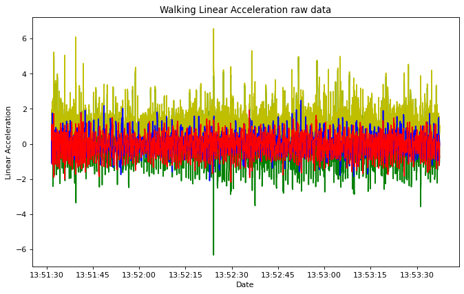

```python
%matplotlib inline
import matplotlib.pyplot as plt
from matplotlib.pyplot import figure

figure(figsize=(10, 6), dpi=80)

plt.plot(walk.iloc[:, 2], 'g-')
plt.plot(walk.iloc[:, 3], 'y-')
plt.plot(walk.iloc[:, 0], 'b-')
plt.plot(walk.iloc[:, 1], 'r-')
plt.title("Walking Linear Acceleration raw data")
plt.xlabel('Date')
plt.ylabel('Linear Acceleration')
```

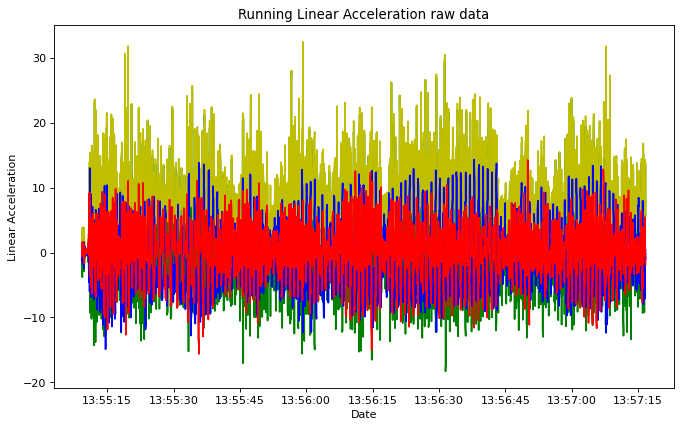

```python
figure(figsize=(10, 6), dpi=80)

plt.plot(run.iloc[:, 2], 'g-')
plt.plot(run.iloc[:, 3], 'y-')
plt.plot(run.iloc[:, 0], 'b-')
plt.plot(run.iloc[:, 1], 'r-')
plt.title("Running Linear Acceleration raw data")
plt.xlabel('Date')
plt.ylabel('Linear Acceleration')
```

The transition times can be seen at the beginning and end of the recordings as have a slightly lower linear acceleration considering all components, seen quite clearly at the beginning of the run recording. And seen slightly (but less obviously) at the start of the walk recording and the end of the run and walk recordings. This is not as obvious for the start of the walk recording and the end of the run and walk recordings because I tried starting running/walking before starting the recording and finishing my running/walking after completing the recording.

## Task 4

```python
walk['delta_t'] = walk.index[:]-walk.index[0]
walk['delta_t'] = walk['delta_t'].astype(str).str.split('0 days ').str[-1]
walk.head()
```

| time | ax | ay | az | \|a\| | delta_t |
| --- | --- | --- | --- | --- | --- |
| 2022-08-16 13:51:31.600 | 0.75 | 0.34 | 1.17 | 1.43 | 00:00:00 |
| 2022-08-16 13:51:31.609 | 0.20 | 0.31 | 1.13 | 1.18 | 00:00:00.009000 |
| 2022-08-16 13:51:31.626 | -0.49 | 0.56 | 0.94 | 1.19 | 00:00:00.026000 |
| 2022-08-16 13:51:31.629 | -0.85 | 0.59 | 0.80 | 1.30 | 00:00:00.029000 |
| 2022-08-16 13:51:31.639 | -1.10 | 0.36 | 0.79 | 1.40 | 00:00:00.039000 |

```python
run['delta_t'] = run.index[:]-run.index[0]
run['delta_t'] = run['delta_t'].astype(str).str.split('0 days ').str[-1]
run.head()
```

| time | ax | ay | az | \|a\| | delta_t |
| --- | --- | --- | --- | --- | --- |
| 2022-08-16 13:55:09.302 | 0.28 | -0.10 | -0.34 | 0.45 | 00:00:00 |
| 2022-08-16 13:55:09.304 | 0.18 | -0.02 | -0.42 | 0.45 | 00:00:00.002000 |
| 2022-08-16 13:55:09.306 | -0.05 | -0.16 | -0.01 | 0.16 | 00:00:00.004000 |
| 2022-08-16 13:55:09.308 | -0.34 | -0.45 | 0.60 | 0.82 | 00:00:00.006000 |
| 2022-08-16 13:55:09.310 | -0.45 | -0.57 | 1.07 | 1.29 | 00:00:00.008000 |

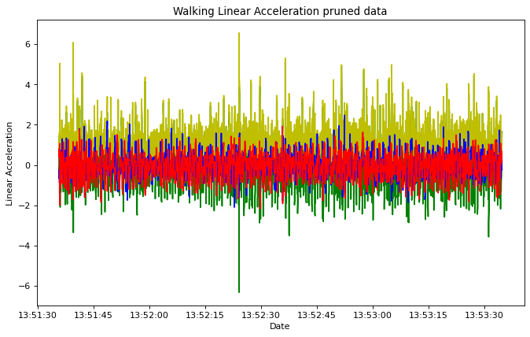

```python
figure(figsize=(10, 6), dpi=80)
walk2 = walk.iloc[400:9400, :]
plt.plot(walk2.iloc[:, 2], 'g-')
plt.plot(walk2.iloc[:, 3], 'y-')
plt.plot(walk2.iloc[:, 0], 'b-')
plt.plot(walk2.iloc[:, 1], 'r-')
plt.title("Walking Linear Acceleration pruned data")
plt.xlabel('Date')
plt.ylabel('Linear Acceleration')
```

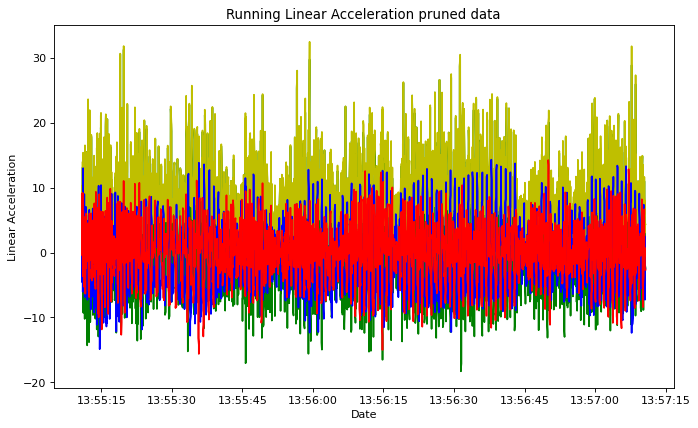

```python
figure(figsize=(10, 6), dpi=80)
run2 = run.iloc[500:9500, :]
plt.plot(run2.iloc[:, 2], 'g-')
plt.plot(run2.iloc[:, 3], 'y-')
plt.plot(run2.iloc[:, 0], 'b-')
plt.plot(run2.iloc[:, 1], 'r-')
plt.title("Running Linear Acceleration pruned data")
plt.xlabel('Date')
plt.ylabel('Linear Acceleration')
```

```python
(walk2.index[-1]-walk2.index[0]).seconds
```

```
119
```

```python
(run2.index[-1]-run2.index[0]).seconds
```

```
119
```

The length of the remaining signals is 119 seconds for both running and walking.

## Task 5

```python
import numpy as np
idx = np.asarray(np.floor(walk2.reset_index().index / 100).values, np.int64)
walk2['window_idx'] = ['w{:02}'.format(i) for i in idx]
walk2.head()
#(walk2.index[:]-walk2.index[0]).seconds
```

| time | ax | ay | az | \|a\| | delta_t | window_idx |
| --- | --- | --- | --- | --- | --- | --- |
| 2022-08-16 13:51:35.616 | -0.33 | 0.48 | -0.13 | 0.59 | 00:00:04.016000 | w00 |
| 2022-08-16 13:51:35.626 | -0.26 | 0.54 | -0.13 | 0.61 | 00:00:04.026000 | w00 |
| 2022-08-16 13:51:35.636 | -0.28 | 0.56 | -0.22 | 0.66 | 00:00:04.036000 | w00 |
| 2022-08-16 13:51:35.646 | -0.30 | 0.61 | -0.29 | 0.73 | 00:00:04.046000 | w00 |
| 2022-08-16 13:51:35.656 | -0.26 | 0.70 | -0.33 | 0.81 | 00:00:04.056000 | w00 |

```python
idx2 = np.asarray(np.floor(run2.reset_index().index / 100).values, np.int64)
run2['window_idx'] = ['r{:02}'.format(i) for i in idx]
run2.head()
```

| time | ax | ay | az | \|a\| | delta_t | window_idx |
| --- | --- | --- | --- | --- | --- | --- |
| 2022-08-16 13:55:10.868 | 1.62 | 2.58 | -0.47 | 3.08 | 00:00:01.566000 | r00 |
| 2022-08-16 13:55:10.871 | 1.74 | 2.48 | -0.22 | 3.03 | 00:00:01.569000 | r00 |
| 2022-08-16 13:55:10.873 | 1.60 | 2.70 | -0.33 | 3.15 | 00:00:01.571000 | r00 |
| 2022-08-16 13:55:10.875 | 1.28 | 3.00 | -0.84 | 3.36 | 00:00:01.573000 | r00 |
| 2022-08-16 13:55:10.877 | 1.15 | 3.21 | -1.19 | 3.61 | 00:00:01.575000 | r00 |

```python
#walk2.shape - (9000 x 6) (both before)
walk2.shape
```

```
(9000, 6)
```

```python
run2.shape
```

```
(9000, 6)
```

```python
# 18000 x 6.
# 180 unique values of window_idx created. (w00-w89), (r00-r89)
combine = pd.concat([run2,walk2])
combine
```

| time | ax | ay | az | \|a\| | delta_t | window_idx |
| --- | --- | --- | --- | --- | --- | --- |
| 2022-08-16 13:55:10.868 | 1.62 | 2.58 | -0.47 | 3.08 | 00:00:01.566000 | r00 |
| 2022-08-16 13:55:10.871 | 1.74 | 2.48 | -0.22 | 3.03 | 00:00:01.569000 | r00 |
| 2022-08-16 13:55:10.873 | 1.60 | 2.70 | -0.33 | 3.15 | 00:00:01.571000 | r00 |
| 2022-08-16 13:55:10.875 | 1.28 | 3.00 | -0.84 | 3.36 | 00:00:01.573000 | r00 |
| 2022-08-16 13:55:10.877 | 1.15 | 3.21 | -1.19 | 3.61 | 00:00:01.575000 | r00 |
| ... | ... | ... | ... | ... | ... | ... |
| 2022-08-16 13:53:34.688 | 0.21 | 0.44 | 0.70 | 0.85 | 00:02:03.088000 | w89 |
| 2022-08-16 13:53:34.690 | -0.11 | 0.68 | 0.66 | 0.95 | 00:02:03.090000 | w89 |
| 2022-08-16 13:53:34.692 | -0.11 | 0.69 | 0.70 | 0.98 | 00:02:03.092000 | w89 |
| 2022-08-16 13:53:34.693 | -0.02 | 0.51 | 1.01 | 1.13 | 00:02:03.093000 | w89 |
| 2022-08-16 13:53:34.800 | -0.23 | 0.19 | 1.65 | 1.67 | 00:02:03.200000 | w89 |

18000 rows × 6 columns

```python
combine.shape
```

```
(18000, 6)
```

Shape of the data frames before was 9000x6 respectively for both running and walking signals, and is now 18000x6 for the combined dataset.

```python
from tsfresh.feature_extraction import extract_features
X = extract_features(combine, column_id = 'window_idx', column_sort = 'delta_t')
```

```python
X.shape
```

```
(180, 3176)
```

180 unique values of column window idx have been generated.

A total of 3176 features have been extracted. The dimensions of the feature matrix being 180x3176.

## Task 6

```python
target = [True for i in range(90)]
target.extend([False for i in range(90)])
target = pd.Series(target)
target.index = X.index
target
```

```
r00     True
r01     True
r02     True
r03     True
r04     True
       ...
w85    False
w86    False
w87    False
w88    False
w89    False
Length: 180, dtype: bool
```

```python
from tsfresh.transformers import FeatureSelector

select = FeatureSelector()
select.fit(X.dropna(axis=1), target)
```

```
FeatureSelector()
```

```python
# 5 features with the smallest p values.
select.relevant_features[0:5]
```

```
['ax__variance_larger_than_standard_deviation',
 'ay__variance_larger_than_standard_deviation',
 '|a|__variance_larger_than_standard_deviation',
 '|a|__number_crossing_m__m_1',
 '|a|__range_count__max_1__min_-1']
```

```python
# p values of the respective features above.
select.p_values[0:5]
```

```
array([2.19750641e-53, 2.19750641e-53, 1.99973083e-51, 8.54629021e-34,
       9.18554040e-34])
```

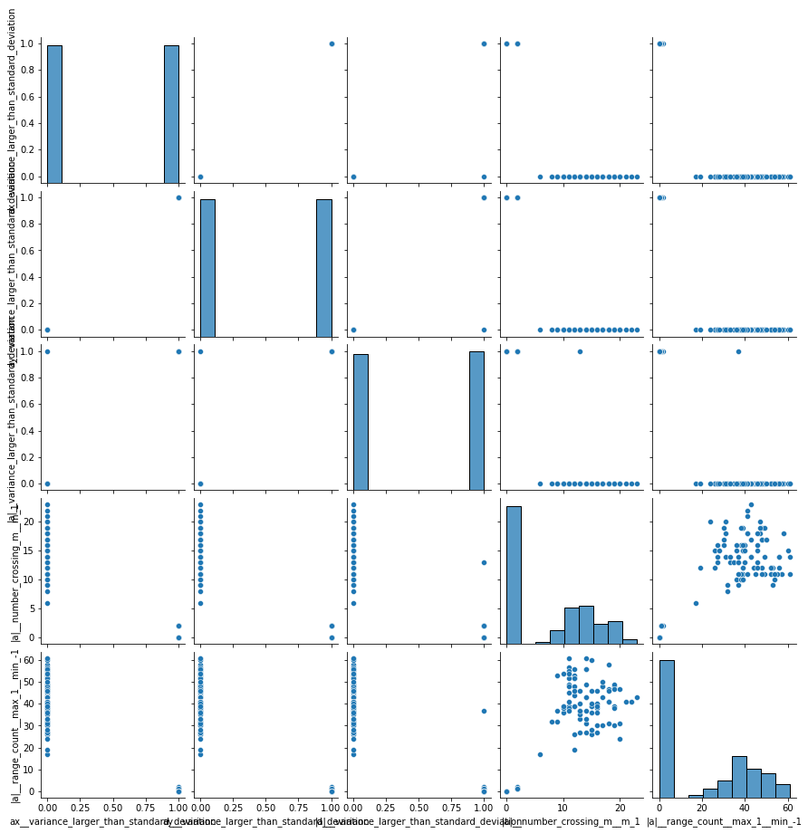

```python
import seaborn as sns
sns.pairplot(X[select.relevant_features[0:5]])
figure(figsize=(30, 30), dpi=80)
```

The first three plots show clear seperation between what would be percieved to be running and walking, whereas while the last two plots also show some seperation between signals, which are slightly closer in comparison to the first three plots but show enough of a difference to distinguish signals relatively easily.

```python
#sklearn.model_selection.RepeatedKFold
from sklearn.ensemble import RandomForestClassifier
from sklearn.model_selection import RepeatedKFold
from sklearn.metrics import roc_auc_score

M = RandomForestClassifier()
rkf = RepeatedKFold(n_splits = 10, n_repeats = 10, random_state = 191856638)
auc = list()
X_rf =  X[select.relevant_features]

for train_index, test_index in rkf.split(X_rf):
    x_train = X_rf.iloc[train_index]
    x_test = X_rf.iloc[test_index]

    x_pred = M.fit(x_train,target[train_index])
    y_pred = x_pred.predict(x_test)

    y = target[test_index].values

    auc.append(roc_auc_score(y,y_pred))

print(sum(auc)/len(auc))
```

```
1.0
```

Model is 100% effective at distinguishing between running and walking signals.

The machine learning model does not know if the costs are different for missclassifications, it assumes costs are identical. Hence a cost of the model could be False Negatives where a person is running slowly but are classified as walking, indiciating health problems potentially which could discourage users of the hypothetical health application. However False Positives wouldn't be as bad of a missclassification as fast walkers being missclassified as runners wouldn't have a negative effect on the user.

This would change the decision model as we would try to minimize the False Negative rate to lead to better health recommendations for the user using the hypothetical health application. So that we could correctly identify slow runners and allow them to feel content about their health by being correctly classified and not discouraged by being misclassified.